# The effect of vapour pressure deficit on Podosphera xanthii germination and germ tube production

The statistical method undertaken in analysing the effect of temperature on *P. xanthii* germination and germ-tube production.

Paul Melloy https://PaulMelloy.github.io (The University of Queensland)https://uq.edu.au  
2022-10-19

## Compendium sections

1. Title page
2. Data preparation and formatting
3. The influence of temperatures on P. xanthii conidia germination
4. The influence of VPD P. xanthii conidia germination and germtube formation

Load R libraries required for analysis

```r
library(data.table) # data structure, cleaning and formatting
library(mgcv) # gam statistical models
library(rstanarm) # Bayesian statistical models
library(ggplot2) # graphing
library(MASS) # logistical ordinal regression functions, among other things
library(splines) # non-linear predictors
library(flextable)
library(marginaleffects) # produce predicted probabilities for polr
source("R/p_star.R")
```

## Impact of vapour pressure deficit on *P. xanthii* germination

Read in data

```r
g_vpd <- fread("cache/germination_vpd.csv")
```

Peek at the data

```r
str(g_vpd)
```

```
Classes 'data.table' and 'data.frame':  288 obs. of  7 variables:
 $ RH        : int  99 99 99 99 99 99 99 99 99 99 ...
 $ Tm        : int  28 28 28 28 28 28 28 28 28 28 ...
 $ vpd       : num  0.038 0.038 0.038 0.038 0.038 0.038 0.038 0.038 0.038 0.038 ...
 $ i_period  : int  12 12 12 12 24 24 24 24 36 36 ...
 $ rep       : int  1 2 3 4 1 2 3 4 1 2 ...
 $ germ_n    : int  56 54 52 50 64 65 60 63 83 80 ...
 $ non_germ_n: int  44 46 48 50 36 35 40 37 17 20 ...
 - attr(*, ".internal.selfref")=<externalptr>
```

```r
# inspect environmental treatments
unique(g_vpd[,.(RH,Tm,vpd)])
```

```
    RH Tm   vpd
 1: 99 28 0.038
 2: 95 28 0.189
 3: 85 28 0.567
 4: 75 28 0.945
 5: 55 28 1.701
 6: 32 28 2.570
 7: 99 25 0.032
 8: 95 25 0.158
 9: 85 25 0.475
10: 75 25 0.792
11: 55 25 1.425
12: 32 25 2.154
13: 99 22 0.026
14: 95 22 0.132
15: 85 22 0.397
16: 75 22 0.661
17: 55 22 1.190
18: 32 22 1.798
```

This table shows there are 18 VPD treatments consisting of six relative humidity and three temperatures.

Sampling times in hours.

```r
g_vpd[, .(reps = paste0(range(rep), collapse = " - ")), by = i_period]
```

```
   i_period  reps
1:       12 1 - 4
2:       24 1 - 4
3:       36 1 - 4
4:       48 1 - 4
```

### Visualise the raw data

Let’s plot the germination over time split by relative humidity.

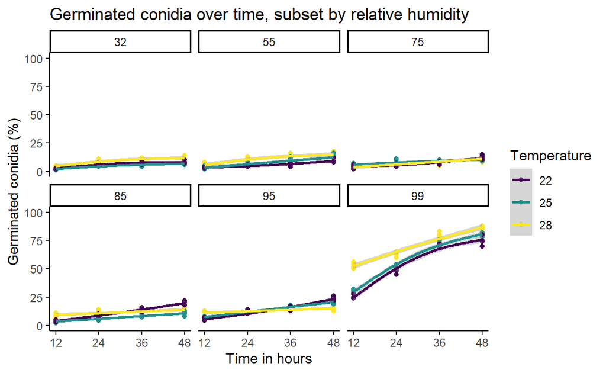

```r
g_vpd |>
   ggplot(aes(x = i_period, y = germ_n, colour = as.factor(Tm))) +
   geom_point()+
   facet_wrap(facets = "RH")+
   geom_smooth(method = "gam",formula = y ~ s(x, k = 3))+
   scale_color_viridis_d()+
   xlab("Time in hours")+
   ylab("Germinated conidia (%)")+
   labs(colour = "Temperature")+
   theme_classic() +
   ggtitle("Germinated conidia over time, subset by relative humidity")+
   scale_x_continuous(limits = c(12,48), breaks = c(12,24,36,48))+
   scale_y_continuous(limits = c(0,100), n.breaks = 5)
```

Germination increases in a linear fashion at all the relative humidity treatments with exception to 99 % humidity, which shows a somewhat non-linear trend in the 22$^\circ$C and 25$^\circ$C temperature treatments.

Let’s look at the same data in terms of VPD split by time.

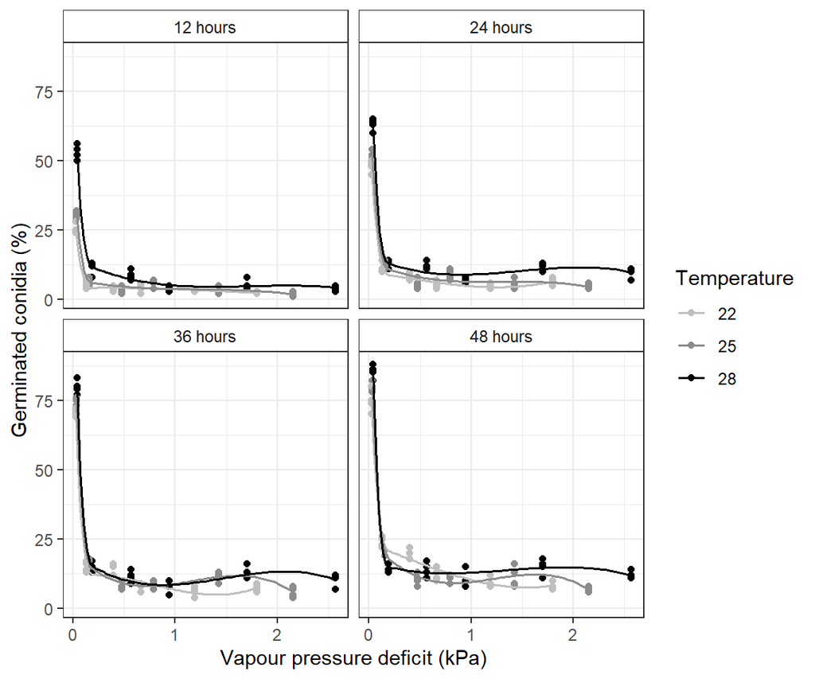

```r
i_p_labs <-c("12 hours","24 hours","36 hours","48 hours")
names(i_p_labs) <- c(12,24,36,48)
g_vpd[, lty := fcase(Tm == 22, "dotted",
                         Tm == 25, "dashed",
                         Tm == 28, "twodash")]
Figure_4 <-
  g_vpd |>
   ggplot(aes(x = vpd, y = germ_n,colour = factor(Tm))) +
   geom_point()+
   theme_bw()+
   scale_color_grey(start = 0.75,end = 0)+
   geom_smooth(method = "gam",
               formula = y ~ bs(x,k=0.2),
               size = 0.7,se = FALSE)+
   facet_wrap(facets = c("i_period"),
              labeller = labeller(i_period = i_p_labs))+
   xlab("Vapour pressure deficit (kPa)")+
   ylab("Germinated conidia (%)")+
   labs(colour = "Temperature")+
   theme_bw()+
   theme(strip.background = element_rect(fill = "white"))
Figure_4
```

Let’s look at the same data in terms of VPD split by temperature.

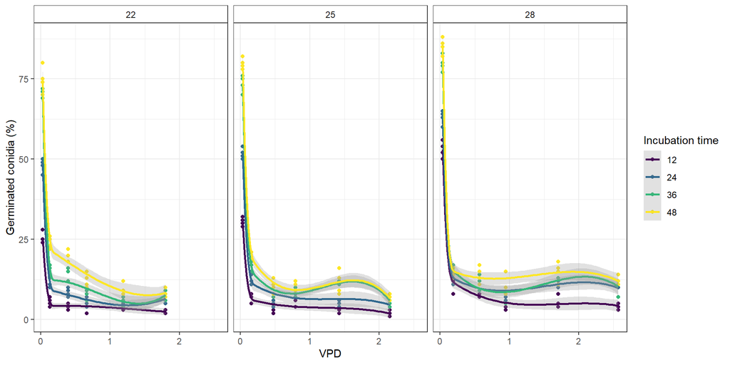

```r
g_vpd |>
   ggplot(aes(x = vpd, y = germ_n, colour = as.factor(i_period))) +
   geom_point()+
   facet_wrap(facets = c("Tm"),nrow = 1)+
   geom_smooth(method = "gam",formula = y ~ bs(x,k=0.2), alpha = 0.3)+
   scale_color_viridis_d()+
   xlab("VPD")+
   ylab("Germinated conidia (%)")+
   labs(colour = "Incubation time")+
   theme_bw()+
   theme(strip.background = element_rect(fill = "white"))
```

This data is very hard to fit a curve to and seems like it would benefit with two functions. Lets plot again without the saturated 99% humidity treatment.

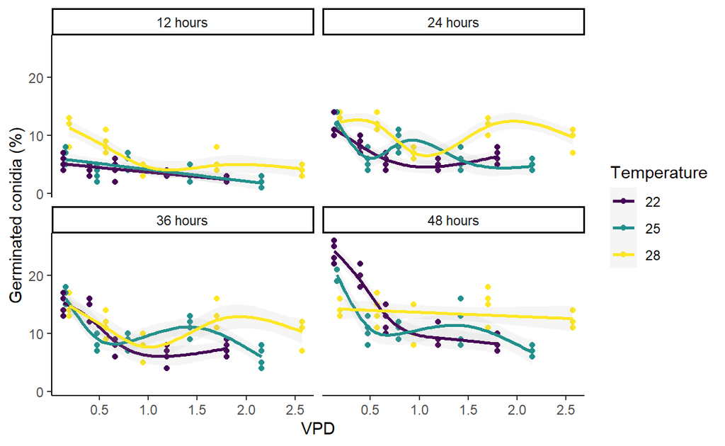

```r
i_p_labs <-c("12 hours","24 hours","36 hours","48 hours")
names(i_p_labs) <- c(12,24,36,48)
g_vpd[g_vpd$RH != 99] |>
   ggplot(aes(x = vpd, y = germ_n, colour = as.factor(Tm))) +
   geom_point()+
   facet_wrap(facets = c("i_period"),
              labeller = labeller(i_period = i_p_labs))+
   geom_smooth(method = "gam",formula = y ~ s(x,k=5), alpha = 0.1)+
   scale_color_viridis_d()+
   xlab("VPD")+
   ylab("Germinated conidia (%)")+
   labs(colour = "Temperature")+
   theme_classic()
```

From these plots it seems that the influence of VPD on germination is bimodal, with an increase in germination between 1.5 and 2 kPa. Particularly in the warmer treatments.

### VPD influence on germination - analysis

Lets start the analysis with a simple model with smoothing terms on VPD, temperature and infection period. We are using a binomial general additive model for all the germination analysis, because it is binary count data. As we saw from plotting the raw data, we likely have non-linear predictors and a `gam` model is a great way to estimate with splines on the predictors.

```r
m1v <- gam(cbind(germ_n,non_germ_n) ~ s(vpd, k = 5) + s(Tm, k = 3) + s(i_period, k = 3),
           data = g_vpd,
           family = "binomial")
summary(m1v)
```

```
Family: binomial
Link function: logit

Formula:
cbind(germ_n, non_germ_n) ~ s(vpd, k = 5) + s(Tm, k = 3) + s(i_period,
    k = 3)

Parametric coefficients:
            Estimate Std. Error z value Pr(>|z|)
(Intercept) -1.97609    0.02141  -92.31   <2e-16 ***
---
Signif. codes:  0 '***' 0.001 '**' 0.01 '*' 0.05 '.' 0.1 ' ' 1

Approximate significance of smooth terms:
              edf Ref.df Chi.sq p-value
s(vpd)      3.995  4.000 4368.0  <2e-16 ***
s(Tm)       1.911  1.992  160.1  <2e-16 ***
s(i_period) 1.966  1.999  679.5  <2e-16 ***
---
Signif. codes:  0 '***' 0.001 '**' 0.01 '*' 0.05 '.' 0.1 ' ' 1

R-sq.(adj) =  0.834   Deviance explained =   82%
UBRE = 3.5896  Scale est. = 1         n = 288
```

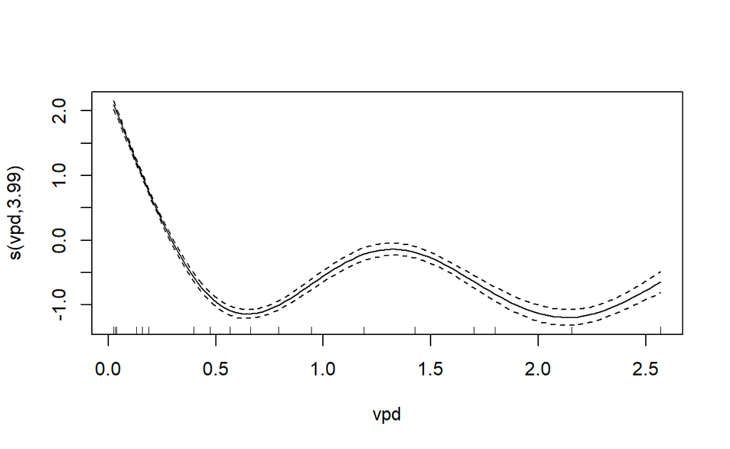

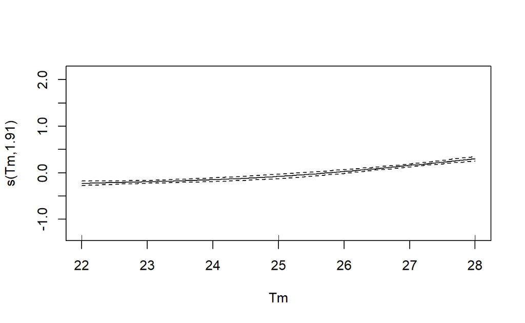

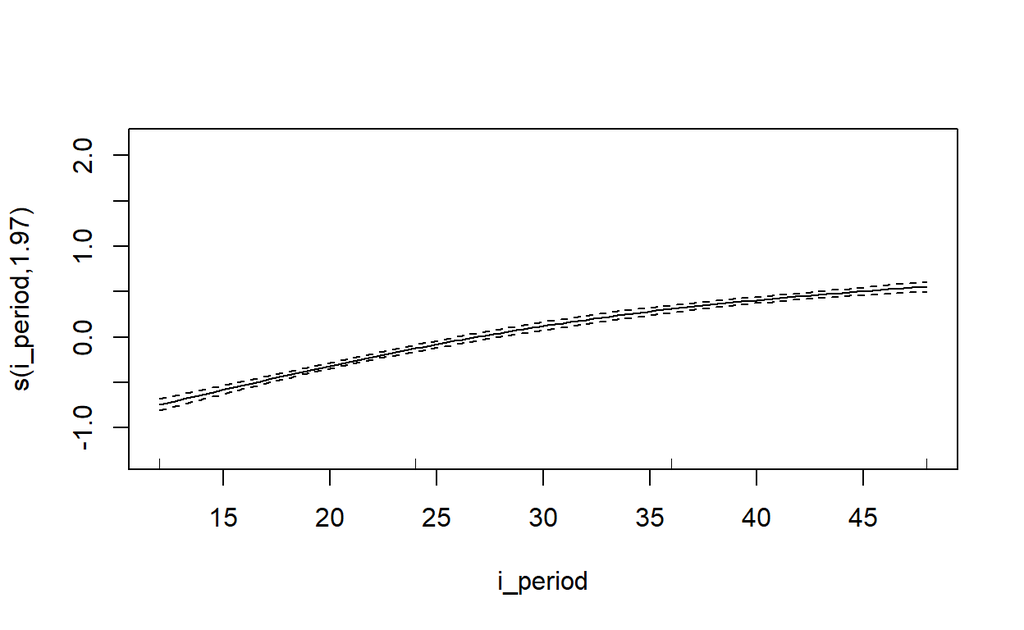

```r
plot(m1v)
```

Overall the model fits very well with a R$^2$ of 0.8337. The splines on `Tm` and `i_period` were statistically significant, and seem to reflect the raw data. Warmer temperatures, from the three temperatures included (22, 25 and 28$^\circ$C) lead to more conidia germinating. Incubation time also showed a positive relationship with the number of germinated conidia, i.e.. the longer the incubation the more conidia were likely to have germinated. VPD also was a significant predictor however the wiggliness might be able to be improved.

As earlier, lets try and reduce the willingness by using P-splines.

```r
m2v <- gam(cbind(germ_n,non_germ_n) ~ s(vpd, k = 5, bs = "ps") + s(Tm, k = 3) + s(i_period, k = 3),
           data = g_vpd,
           family = "binomial")
summary(m2v)
```

```
Family: binomial
Link function: logit

Formula:
cbind(germ_n, non_germ_n) ~ s(vpd, k = 5, bs = "ps") + s(Tm,
    k = 3) + s(i_period, k = 3)

Parametric coefficients:
            Estimate Std. Error z value Pr(>|z|)
(Intercept) -1.98330    0.02141  -92.65   <2e-16 ***
---
Signif. codes:  0 '***' 0.001 '**' 0.01 '*' 0.05 '.' 0.1 ' ' 1

Approximate significance of smooth terms:
              edf Ref.df Chi.sq p-value
s(vpd)      3.996  4.000 4652.2  <2e-16 ***
s(Tm)       1.903  1.991  170.4  <2e-16 ***
s(i_period) 1.968  1.999  693.6  <2e-16 ***
---
Signif. codes:  0 '***' 0.001 '**' 0.01 '*' 0.05 '.' 0.1 ' ' 1

R-sq.(adj) =  0.889   Deviance explained = 86.5%
UBRE = 2.4425  Scale est. = 1         n = 288
```

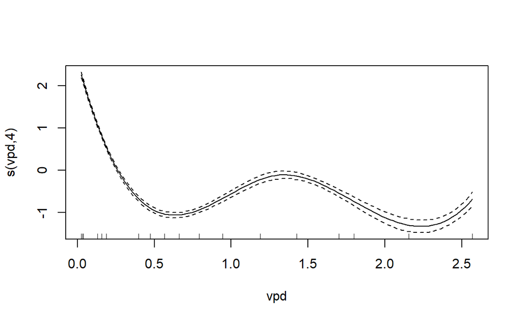

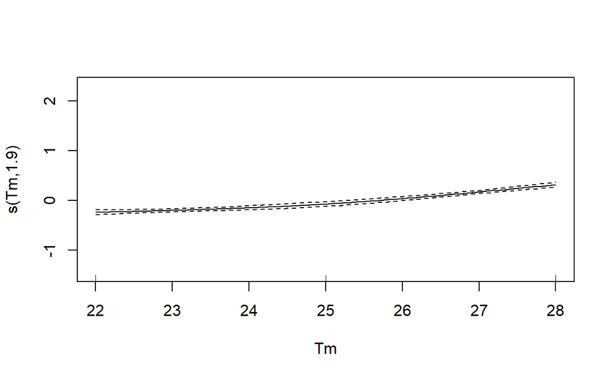

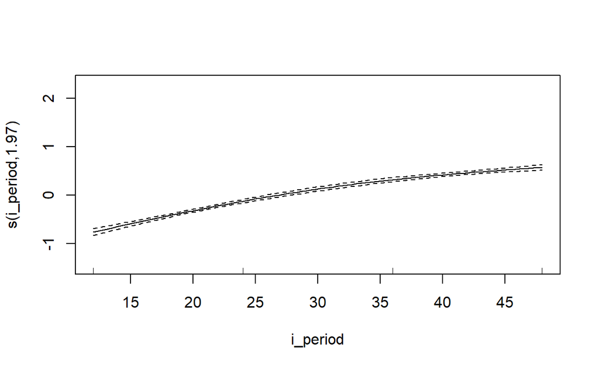

```r
plot(m2v)
```

This shows only a small improvement and a decreasing trend in the VPD plot.

Next lets try more VPD spline knots.

```r
m3v <- gam(cbind(germ_n,non_germ_n) ~ s(vpd, k = 7, bs = "ps") + s(Tm, k = 3) + s(i_period, k = 3),
           data = g_vpd,
           family = "binomial")
summary(m3v)
```

```
Family: binomial
Link function: logit

Formula:
cbind(germ_n, non_germ_n) ~ s(vpd, k = 7, bs = "ps") + s(Tm,
    k = 3) + s(i_period, k = 3)

Parametric coefficients:
            Estimate Std. Error z value Pr(>|z|)
(Intercept) -1.96325    0.02119  -92.63   <2e-16 ***
---
Signif. codes:  0 '***' 0.001 '**' 0.01 '*' 0.05 '.' 0.1 ' ' 1

Approximate significance of smooth terms:
              edf Ref.df Chi.sq p-value
s(vpd)      5.971  5.999 5167.6  <2e-16 ***
s(Tm)       1.726  1.924  154.1  <2e-16 ***
s(i_period) 1.971  1.999  717.8  <2e-16 ***
---
Signif. codes:  0 '***' 0.001 '**' 0.01 '*' 0.05 '.' 0.1 ' ' 1

R-sq.(adj) =   0.95   Deviance explained =   93%
UBRE = 0.82596  Scale est. = 1         n = 288
```

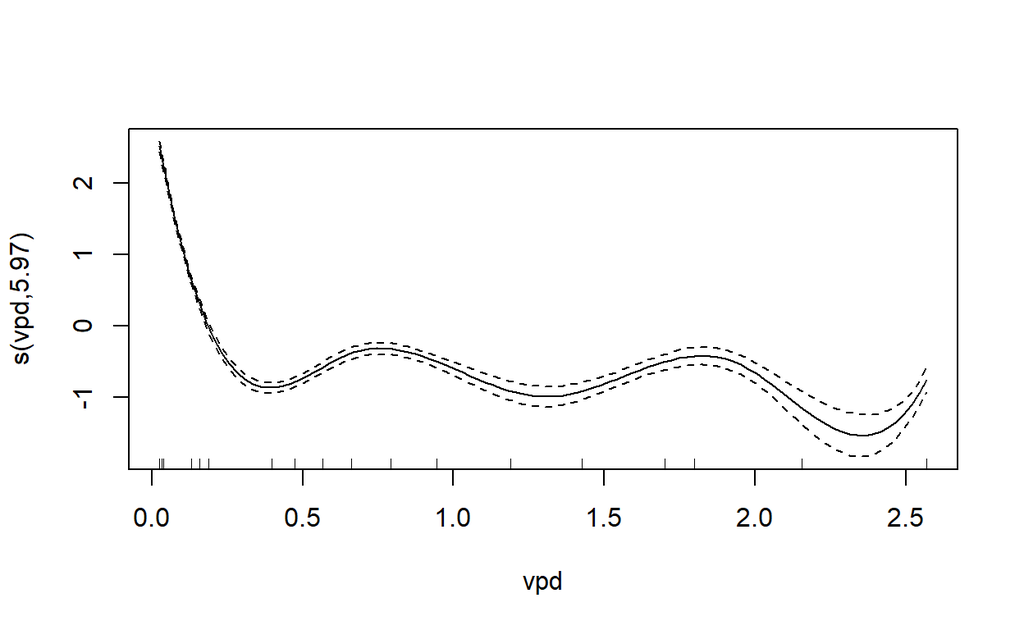

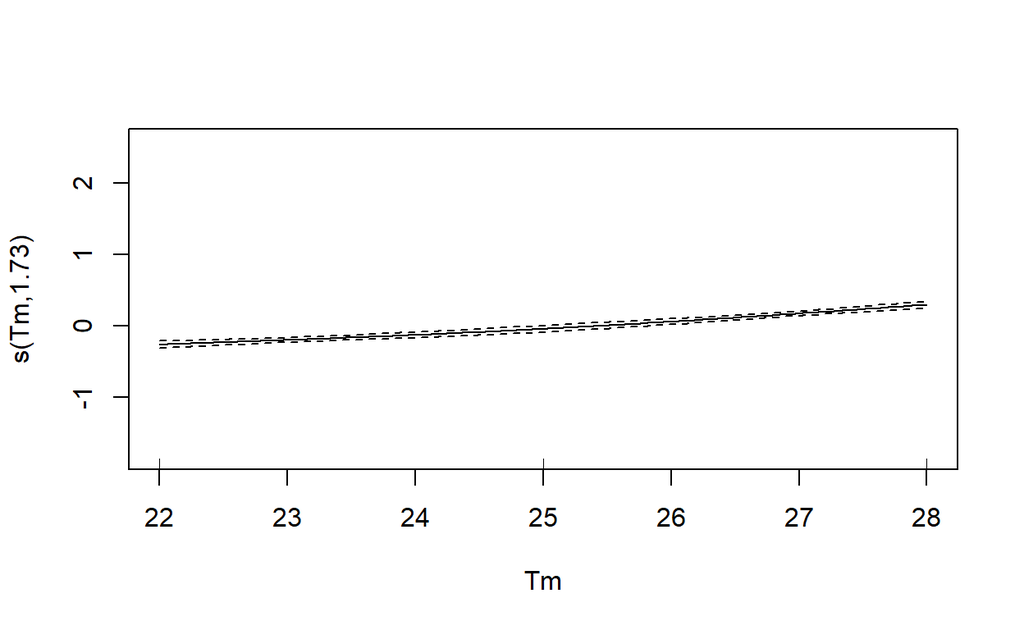

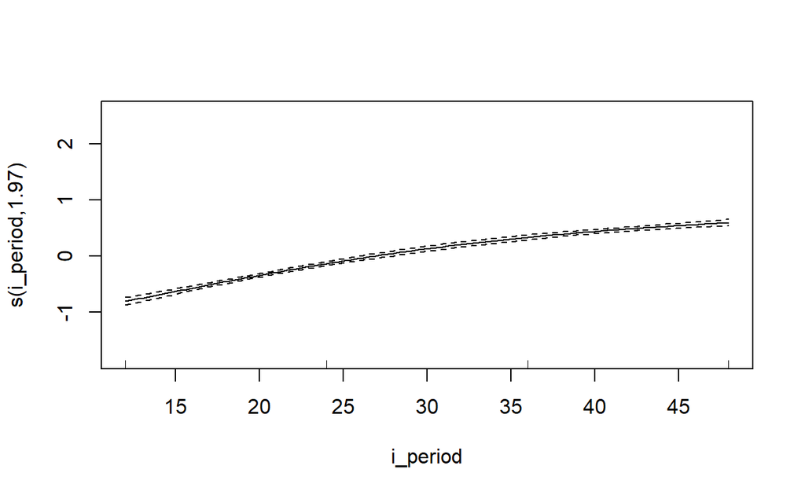

```r
plot(m3v)
```

Temperature does not seem like it needs a non-linear term. The next model will test this assumption.

```r
m4v <- gam(cbind(germ_n,non_germ_n) ~ s(vpd, k = 7) + Tm + s(i_period,k=3),
           data = g_vpd,
           family = "binomial")
summary(m4v)
```

```
Family: binomial
Link function: logit

Formula:
cbind(germ_n, non_germ_n) ~ s(vpd, k = 7) + Tm + s(i_period,
    k = 3)

Parametric coefficients:
             Estimate Std. Error z value Pr(>|z|)
(Intercept) -4.009685   0.190921  -21.00   <2e-16 ***
Tm           0.080869   0.007478   10.81   <2e-16 ***
---
Signif. codes:  0 '***' 0.001 '**' 0.01 '*' 0.05 '.' 0.1 ' ' 1

Approximate significance of smooth terms:
              edf Ref.df Chi.sq p-value
s(vpd)      5.990  6.000 4868.3  <2e-16 ***
s(i_period) 1.969  1.999  705.5  <2e-16 ***
---
Signif. codes:  0 '***' 0.001 '**' 0.01 '*' 0.05 '.' 0.1 ' ' 1

R-sq.(adj) =  0.928   Deviance explained = 90.1%
UBRE = 1.5636  Scale est. = 1         n = 288
```

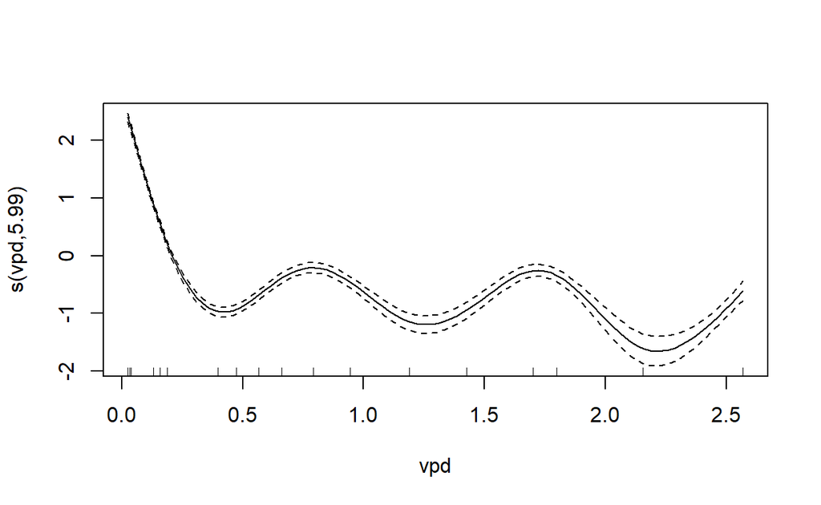

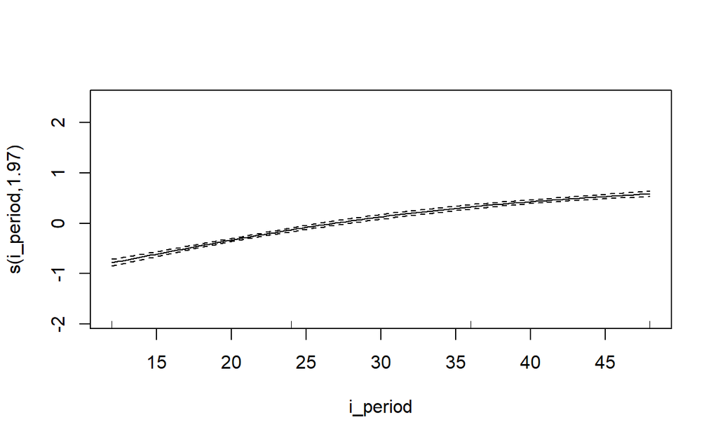

```r
plot(m4v)
```

There is a slight reduction in the model fit, as shown by the difference in the R$^2$ and UBRE values between m3v and m4v.

In addition the wiggliness of the VPD curve seems more pronounced. We will next evaluate if there is an interaction between VPD and temperature, which should also help us decide if temperature should be a linear or non-linear term.

```r
m5v <- gam(cbind(germ_n,non_germ_n) ~ te(vpd,Tm, k = 3)+ s(i_period,k=3),
           data = g_vpd,
           family = "binomial")
summary(m5v)
```

```
Family: binomial
Link function: logit

Formula:
cbind(germ_n, non_germ_n) ~ te(vpd, Tm, k = 3) + s(i_period,
    k = 3)

Parametric coefficients:
            Estimate Std. Error z value Pr(>|z|)
(Intercept) -1.95016    0.02132  -91.47   <2e-16 ***
---
Signif. codes:  0 '***' 0.001 '**' 0.01 '*' 0.05 '.' 0.1 ' ' 1

Approximate significance of smooth terms:
              edf Ref.df Chi.sq p-value
te(vpd,Tm)  7.867  7.987 3652.8  <2e-16 ***
s(i_period) 1.965  1.999  650.1  <2e-16 ***
---
Signif. codes:  0 '***' 0.001 '**' 0.01 '*' 0.05 '.' 0.1 ' ' 1

R-sq.(adj) =  0.697   Deviance explained =   71%
UBRE = 6.3679  Scale est. = 1         n = 288
```

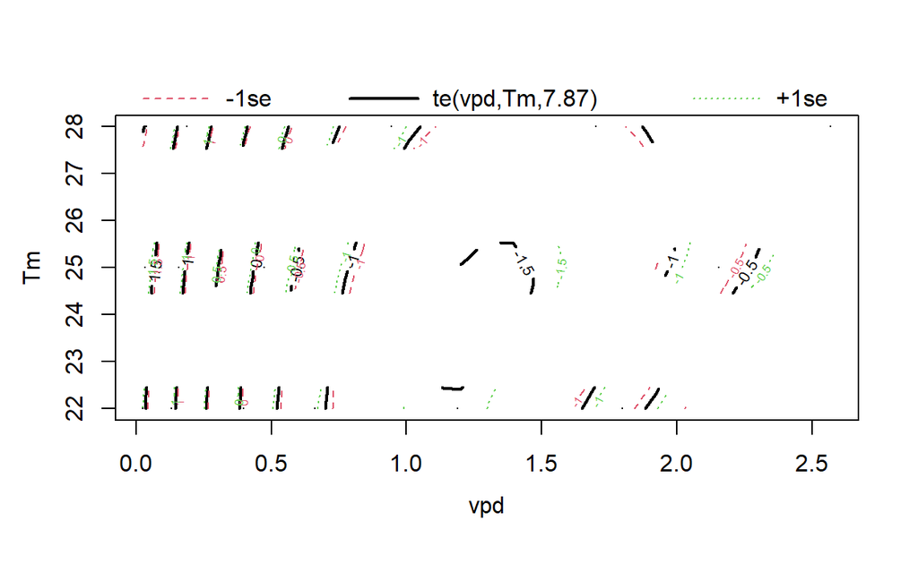

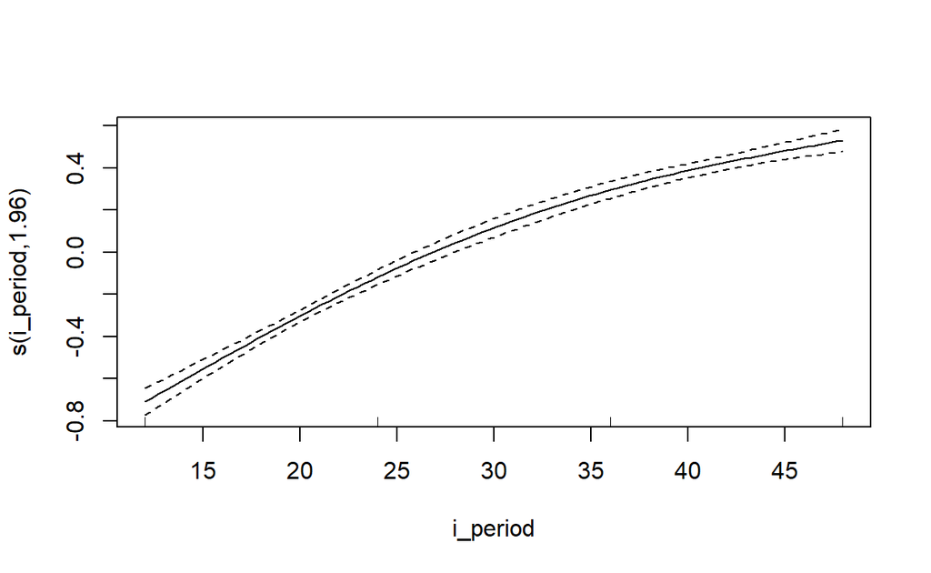

```r
plot(m5v)
```

```r
anova(m4v,m5v)
```

```
Analysis of Deviance Table

Model 1: cbind(germ_n, non_germ_n) ~ s(vpd, k = 7) + Tm + s(i_period,
    k = 3)
Model 2: cbind(germ_n, non_germ_n) ~ te(vpd, Tm, k = 3) + s(i_period,
    k = 3)
  Resid. Df Resid. Dev      Df Deviance
1    278.00     718.41
2    277.01    2100.29 0.98715  -1381.9
```

This comparison shows while the interaction between temperature is significant, the m5v model does not fit the data as well as m4v .

Because of the rapid drop in germination in the lower VPD range, and little change between the higher VPD treatments, it is difficult to fit a non-linear model with evenly spaced splines. Also we don’t have enough evenly spaced VPD treatments to increase the number of knots without causing an over fit model. We can override this default behaviour of splines placed at set points by specifying our own knot points.

Here we will specify two knots at 0.1 kPa and 0.4 kPa, in addition to the boundary knots.

```r
b_k <- range(g_vpd$vpd) # set spline boundary knots
m6v <- gam(cbind(germ_n,non_germ_n) ~ s(vpd, k = 4,bs = "cs") + Tm + s(i_period,k=3),
           knots = list(vpd = c(b_k[1],0.1,0.4,b_k[2])),
           data = g_vpd,
           family = "binomial")


summary(m6v)
```

```
Family: binomial
Link function: logit

Formula:
cbind(germ_n, non_germ_n) ~ s(vpd, k = 4, bs = "cs") + Tm + s(i_period,
    k = 3)

Parametric coefficients:
            Estimate Std. Error z value Pr(>|z|)
(Intercept) -4.48276    0.19318  -23.20   <2e-16 ***
Tm           0.10138    0.00757   13.39   <2e-16 ***
---
Signif. codes:  0 '***' 0.001 '**' 0.01 '*' 0.05 '.' 0.1 ' ' 1

Approximate significance of smooth terms:
              edf Ref.df Chi.sq p-value
s(vpd)      2.999  3.000 5302.4  <2e-16 ***
s(i_period) 1.971  1.999  723.7  <2e-16 ***
---
Signif. codes:  0 '***' 0.001 '**' 0.01 '*' 0.05 '.' 0.1 ' ' 1

R-sq.(adj) =  0.958   Deviance explained = 94.1%
UBRE = 0.52704  Scale est. = 1         n = 288
```

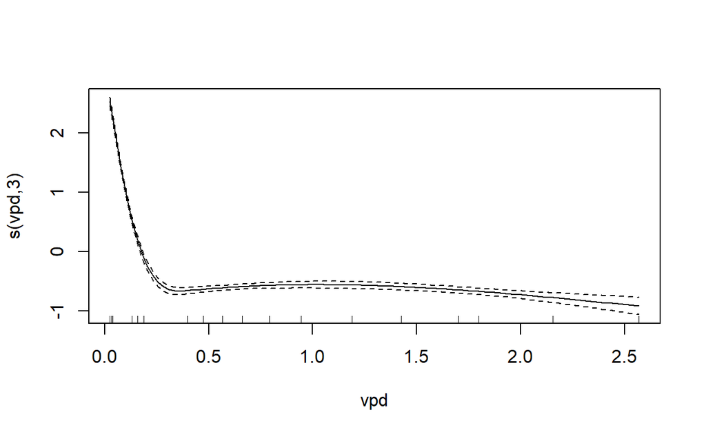

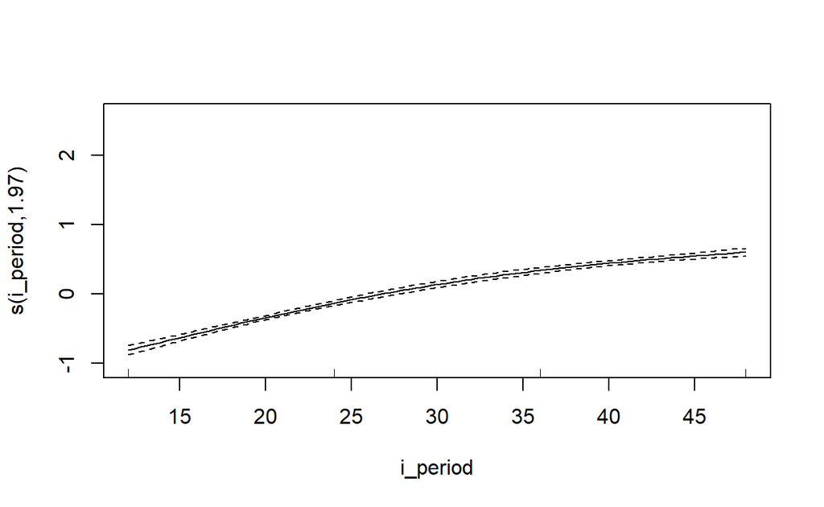

```r
plot(m6v)
```

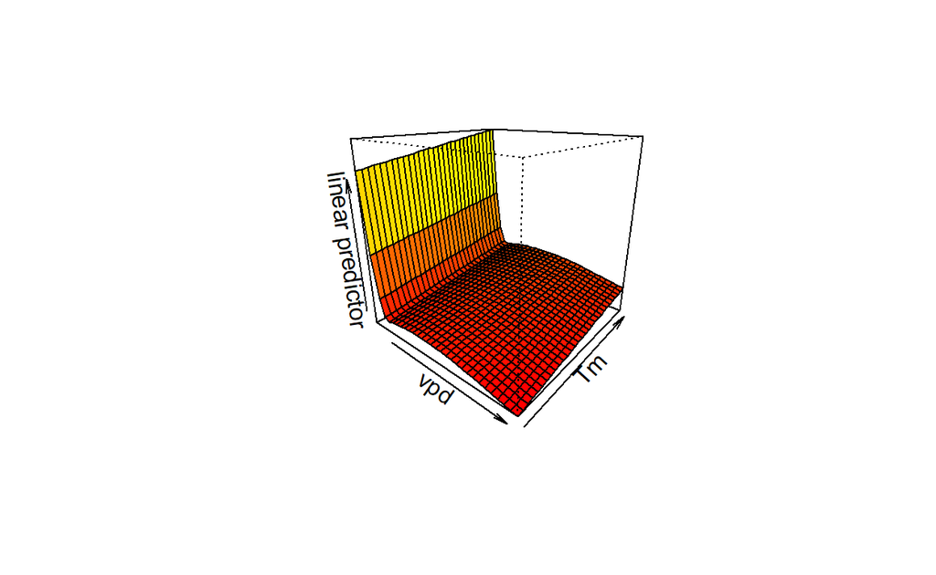

```r
vis.gam(m6v,
        phi = 20,
        theta = 40,
        view = c("vpd","Tm"),
        )
```

This model presents the best fit model so far, as shown by the R$^2$ value of 0.9582, 94.12% deviance explained and 0.5270411UBRE.

Let’s compare the models side-by-side using the ‘Akaike Information Criterion’ (AIC). A lower number is generally viewed as indicating a better model fit.

```r
AIC(m1v,m2v,m3v, m4v, m5v, m6v)
```

```
           df      AIC
m1v  8.872701 2477.644
m2v  8.867062 2147.279
m3v 10.667524 1681.719
m4v  9.958923 1894.166
m5v 10.831486 3277.794
m6v  6.970012 1595.630
```

Model six (`m6v`) shows the best fit to the raw data plotted in Figure 4.

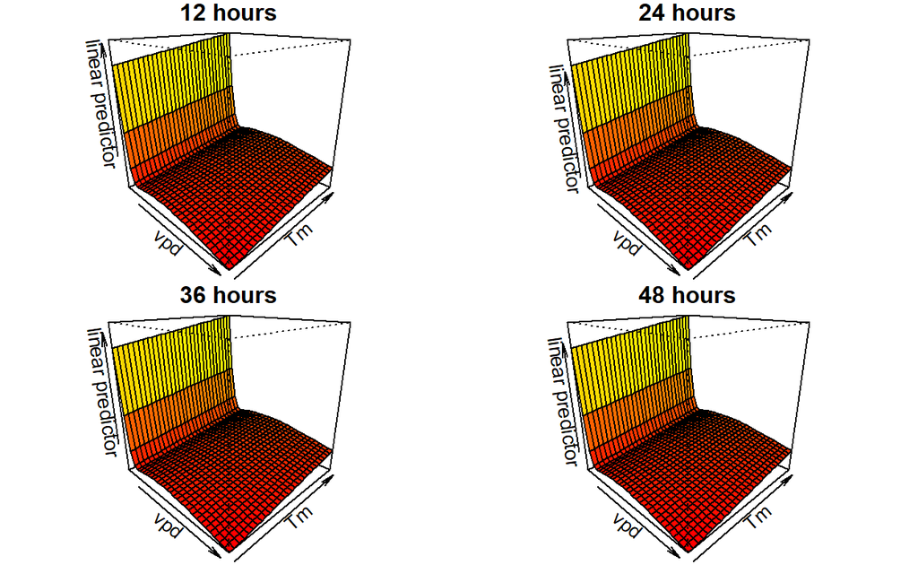

```r
# subset by incubation time
par(mfrow = c(2,2),
    oma = c(0,0,0,0),
    mar = c(0.1,0.1,1,0.1))
vis.gam(m6v,
        phi = 20,
        theta = 45,
        view = c("vpd","Tm"),
        cond = list(i_period = 12),
        main = "12 hours")
vis.gam(m6v,
        phi = 20,
        theta = 45,
        view = c("vpd","Tm"),
        cond = list(i_period = 24),
        main = "24 hours")
vis.gam(m6v,
        phi = 20,
        theta = 45,
        view = c("vpd","Tm"),
        cond = list(i_period = 36),
        main = "36 hours")
vis.gam(m6v,
        phi = 20,
        theta = 45,
        view = c("vpd","Tm"),
        cond = list(i_period = 48),
        main = "48 hours")
```

```r
par(mfrow = c(1,1))
```

### Visualise model against the raw data

To simulate data from the model using `predict` we need to provide some values which to estimate over.

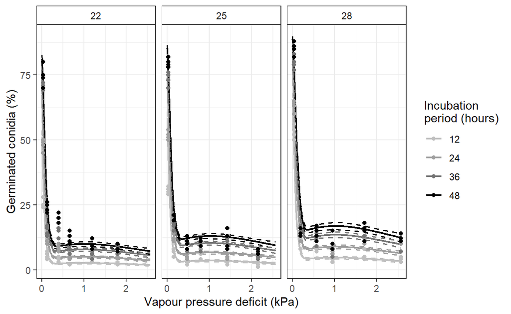

```r
# Make a data.frame of test values to feed in the model
test_vpd <- rep(seq(from = 0, to = max(g_vpd$vpd), by = 0.01), 3*4)
test_dat <- data.table(vpd = test_vpd, # between 5 and 8 degrees for each incubation period
                       Tm = rep(unique(g_vpd$Tm),
                                each = length(test_vpd),
                                times = 4),
                       i_period = rep(c(12,24,36,48), each = length(test_vpd)*3))

# create a data.frame with predicted values and reference them to the respective temperature
m6_pred_list <-
   predict(m6v,
           test_dat,
           type = "response",
           se.fit = TRUE)
m6_pred <- data.table(vpd = test_dat$vpd,
                      Tm = as.factor(test_dat$Tm),
                      i_period = as.factor(test_dat$i_period),
                      germinated = m6_pred_list$fit,
                      germ_se = m6_pred_list$se.fit,
                      CI_low = m6_pred_list$fit + (m6_pred_list$se.fit * -1.94),
                      CI_high = m6_pred_list$fit + (m6_pred_list$se.fit * 1.94))

Figure_4 <-
   m6_pred |>
   ggplot(aes(x = vpd, y = germinated*100, colour = i_period))+
   facet_wrap(facets = c("Tm"))+
              #labeller = labeller(i_period = i_p_labs))+
   geom_line(size = 0.8)+
   scale_color_grey(start = 0.75,end = 0)+
   theme_bw()+
   geom_line(aes(x = vpd, y = CI_low*100), linetype = "dashed", size = 0.6)+
   geom_line(aes(x = vpd, y = CI_high*100), linetype = "dashed", size = 0.6)+
   xlab("Vapour pressure deficit (kPa)")+
   ylab("Germinated conidia (%)")+
   labs(colour = "Incubation\nperiod (hours)")+
   geom_point(data = g_vpd,
              aes(x = vpd, y = (germ_n),
                  colour = as.factor(i_period)))+
   theme(strip.background = element_rect(fill = "white"))

Figure_4
```

## Impact of VPD on *P. xanthii* branching

Import the clean data

```r
# Read clean data
b_vpd <- fread("cache/branching_vpd.csv")[, exp := 1]
b_vpd2 <- fread("cache/branching_VPD2.csv")[,exp := 2]
b_vpd3 <- fread("cache/branching_VPD3.csv")[,exp := 3]
```

There were three data-sets which recorded germ-tube formation at a range of VPD.

Lets look at the summaries of the data.

```r
rmarkdown::paged_table(b_vpd[, list(
   Mean = mean(conidia),
   Std_dev = round(sd(conidia), 3),
   Median = median(conidia),
   Range = paste0(range(conidia), collapse = " - "),
   Replicates = .N),
   by = .(vpd, Tm, germtubes)])
```

| vpd | Tm | germtubes | Mean | Std_dev | Median | Range | Replicates |
| --- | --- | --- | --- | --- | --- | --- | --- |
| 0.026 | 22 | 0 | 0.50 | 1.000 | 0.0 | 0 - 2 | 4 |
| 0.132 | 22 | 0 | 71.25 | 6.131 | 70.5 | 65 - 79 | 4 |
| 0.397 | 22 | 0 | 74.25 | 3.862 | 75.0 | 69 - 78 | 4 |
| 0.661 | 22 | 0 | 82.00 | 4.082 | 83.5 | 76 - 85 | 4 |
| 1.190 | 22 | 0 | 85.00 | 4.243 | 84.5 | 81 - 90 | 4 |
| 1.798 | 22 | 0 | 87.50 | 5.508 | 87.0 | 82 - 94 | 4 |
| 0.026 | 22 | 1 | 12.50 | 2.517 | 12.0 | 10 - 16 | 4 |
| 0.132 | 22 | 1 | 23.00 | 4.163 | 23.0 | 18 - 28 | 4 |
| 0.397 | 22 | 1 | 21.00 | 4.163 | 21.0 | 16 - 26 | 4 |
| 0.661 | 22 | 1 | 14.00 | 4.320 | 13.0 | 10 - 20 | 4 |

[output cut: 62 more lines]

```r
rmarkdown::paged_table(b_vpd2[, list(
   Mean = mean(conidia),
   Std_dev = round(sd(conidia), 3),
   Median = median(conidia),
   Range = paste0(range(conidia), collapse = " - "),
   Replicates = .N),
   by = .(vpd, Tm, germtubes)])
```

| vpd | Tm | germtubes | Mean | Std_dev | Median | Range | Replicates |
| --- | --- | --- | --- | --- | --- | --- | --- |
| 0.026 | 22 | 0 | 30.50 | 4.950 | 30.5 | 27 - 34 | 2 |
| 0.132 | 22 | 0 | 86.00 | 2.449 | 86.0 | 83 - 89 | 4 |
| 0.397 | 22 | 0 | 87.75 | 2.217 | 87.0 | 86 - 91 | 4 |
| 0.661 | 22 | 0 | 90.75 | 1.500 | 91.0 | 89 - 92 | 4 |
| 1.190 | 22 | 0 | 92.00 | 1.414 | 91.5 | 91 - 94 | 4 |
| 1.798 | 22 | 0 | 93.75 | 1.500 | 94.0 | 92 - 95 | 4 |
| 0.026 | 22 | 1 | 6.50 | 2.121 | 6.5 | 5 - 8 | 2 |
| 0.132 | 22 | 1 | 0.25 | 0.500 | 0.0 | 0 - 1 | 4 |
| 0.397 | 22 | 1 | 0.25 | 0.500 | 0.0 | 0 - 1 | 4 |
| 0.661 | 22 | 1 | 1.50 | 0.577 | 1.5 | 1 - 2 | 4 |

[output cut: 62 more lines]

```r
rmarkdown::paged_table(b_vpd3[, list(
   Mean = mean(conidia),
   Std_dev = round(sd(conidia), 3),
   Median = median(conidia),
   Range = paste0(range(conidia), collapse = " - "),
   Replicates = .N),
   by = .(vpd, Tm, germtubes)])
```

| vpd | Tm | germtubes | Mean | Std_dev | Median | Range | Replicates |
| --- | --- | --- | --- | --- | --- | --- | --- |
| 0.026 | 22 | 0 | 31.00 | 13.638 | 28.5 | 19 - 48 | 4 |
| 0.132 | 22 | 0 | 85.00 | 9.899 | 87.5 | 71 - 94 | 4 |
| 0.397 | 22 | 0 | 86.00 | 5.228 | 86.0 | 81 - 91 | 4 |
| 0.661 | 22 | 0 | 92.00 | 3.266 | 92.0 | 88 - 96 | 4 |
| 1.190 | 22 | 0 | 94.00 | 3.367 | 94.0 | 90 - 98 | 4 |
| 1.798 | 22 | 0 | 93.50 | 1.915 | 93.0 | 92 - 96 | 4 |
| 0.026 | 22 | 1 | 9.00 | 4.967 | 8.5 | 4 - 15 | 4 |
| 0.132 | 22 | 1 | 8.00 | 4.967 | 7.5 | 3 - 14 | 4 |
| 0.397 | 22 | 1 | 7.50 | 3.416 | 7.0 | 4 - 12 | 4 |
| 0.661 | 22 | 1 | 4.25 | 2.630 | 3.5 | 2 - 8 | 4 |

[output cut: 62 more lines]

We will combine the data into one object to interrogate.

```r
b_v <-rbind(b_vpd,b_vpd2,b_vpd3)
```

### Visualise the raw data

First we want observe the effect of VPD on the number of germtubes at 36 hours for each experimental rep.

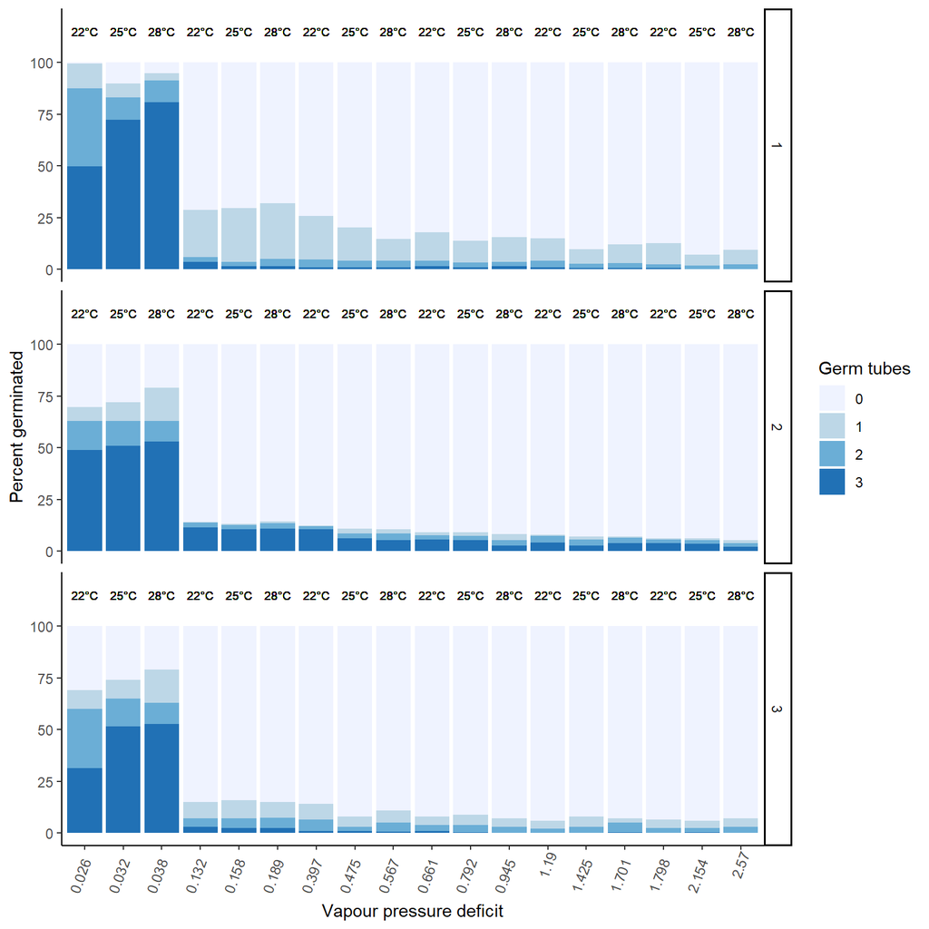

```r
b_v[,percent := (conidia/sum(conidia))*100,
    by = .(vpd,exp)]
b_v |>
   ggplot(aes( x = as.factor(vpd),
               y = percent ,
               fill = as.factor(germtubes))) +
   geom_col()+
   facet_grid(rows = vars(exp))+
   scale_fill_brewer(palette = "Blues", name = "Germ tubes")+
   xlab("Vapour pressure deficit")+
   ylab("Percent germinated")+
   labs(colour = "Germ tubes")+
   theme_classic()+
   theme(axis.text.x = element_text(angle = 70, vjust = 1.7, hjust = 2))+
   geom_text(aes(x = as.factor(vpd), y = 115, label = paste0(Tm,"°C")),size = 2.5)+
   scale_y_continuous(limits = c(0,120), breaks = c(0,25,50,75,100))
```

Each experiment has similar trends and different variation for each VPD probably due to the temperature incubation.

Next lets look at a consolidated graph with all the experimental reps together.

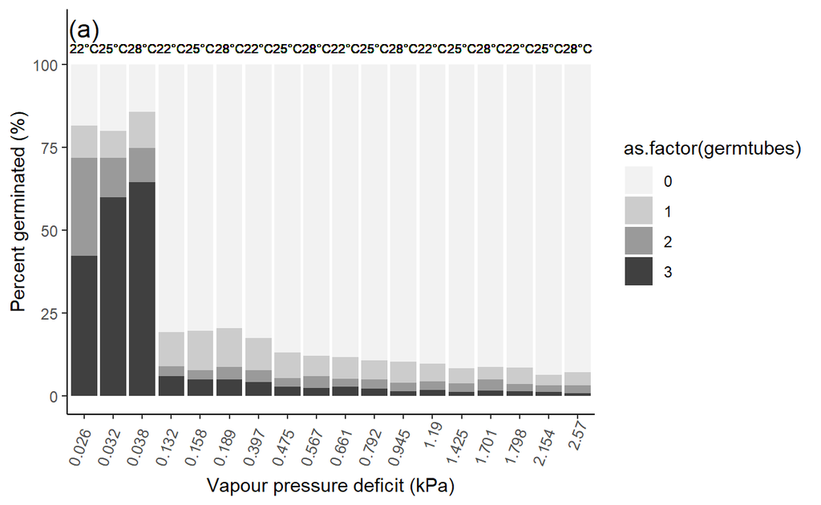

```r
b_v[,percent := (conidia/sum(conidia))*100,
    by = .(vpd)]

Figure_5 <-
   b_v |>
   ggplot(aes( x = as.factor(vpd),
               y = percent ,
               fill = as.factor(germtubes))) +
   geom_col()+
   scale_fill_manual(values = c("0" = "grey90",
                                "1" = "grey70",
                                "2" = "grey55",
                                "3" = "grey40"),
                     name = "Germ tubes")+
   xlab("Vapour pressure deficit (kPa)")+
   ylab("Percent germinated (%)")+
   labs(colour = "Germ tubes")+
   theme_classic()+
   scale_fill_grey(start = 0.95,end = 0.25)+
   theme(axis.text.x = element_text(angle = 70, vjust = 1.7, hjust = 2))+
   geom_text(aes(x = as.factor(vpd), y = 105, label = paste0(Tm,"°C")),size = 2.5)+
   scale_y_continuous(limits = c(0,111), breaks = c(0,25,50,75,100))+
   annotate("text", x = 1, y = 111, label = "(a)", size =5)
Figure_5
```

### Analysis of conidial germination and germtube proliferation

In order to analyse the data we need to set the data classes.

```r
b_v[, c("exp",
              "rep",
              "germtubes",
              "cham",
              "vpd") := list(as.factor(exp),
                             as.integer(rep),
                             as.ordered(germtubes),
                             paste0(Tm, RH),
                             as.numeric(vpd))]
```

First we start with a simple additive model with no interaction or smooths.

```r
m1 <- polr(germtubes ~ vpd + Tm + exp,
           weights = conidia,
           data = b_v, Hess = TRUE)

summary(m1)
```

```
Call:
polr(formula = germtubes ~ vpd + Tm + exp, data = b_v, weights = conidia,
    Hess = TRUE)

Coefficients:
        Value Std. Error t value
vpd  -1.81748   0.039186 -46.381
Tm    0.05095   0.007146   7.129
exp2 -0.78489   0.044774 -17.530
exp3 -0.59512   0.040611 -14.654

Intercepts:
    Value    Std. Error t value
0|1   0.9503   0.1794     5.2981
1|2   1.5189   0.1795     8.4605
2|3   2.0327   0.1801    11.2889

Residual Deviance: 28328.77
AIC: 28342.77
```

Lets try predicting from this model so we can plot how it performs. First we need to make some test data.

```r
# Make a data.frame of test values to feed in the model
test_dat <- data.table(Tm = rep(seq(from = 22, to = 28, by = 1),
                                each = 256,
                                times = 3), # between 5 and 8 degrees
                       vpd = rep(seq(from = 0.020, to = 2.57, by = 0.01),
                                 times = 7*3),
                       exp = as.factor(rep(1:3,
                                 each = 7*256))
                       )
```

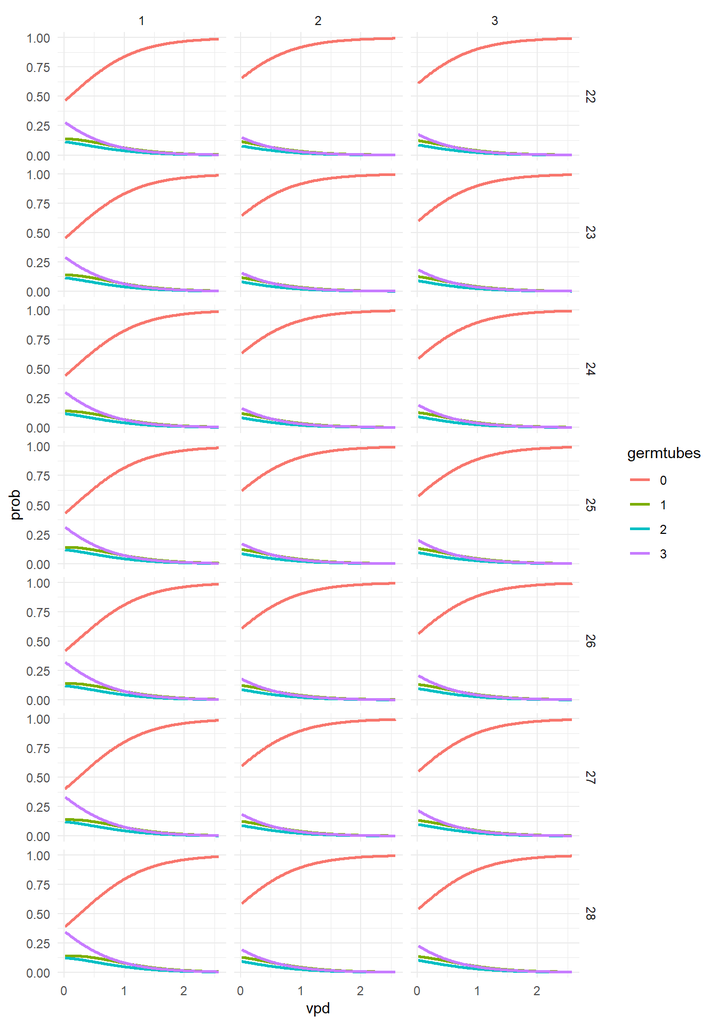

```r
# create a data.frame with predicted values and reference them to the respective temperature
m1_pred <-
   as.data.table(cbind(test_dat,
                       round(predict(m1,
                                     test_dat,
                                     type = "p"),
                             3)))

# format to long
m1_pred <-
   melt(
      m1_pred,
      id.vars = c("Tm","vpd","exp"),
      measure.vars = c("0", "1", "2", "3"),
      variable.name = "germtubes",
      value.name = "prob"
   )

# Plot the predicted model
m1_pred |>
   ggplot(aes(x = vpd, y = prob, colour = germtubes))+
   facet_grid(rows = vars(Tm), cols = vars(exp))+
   geom_line(size = 1)+
   theme_minimal()
```

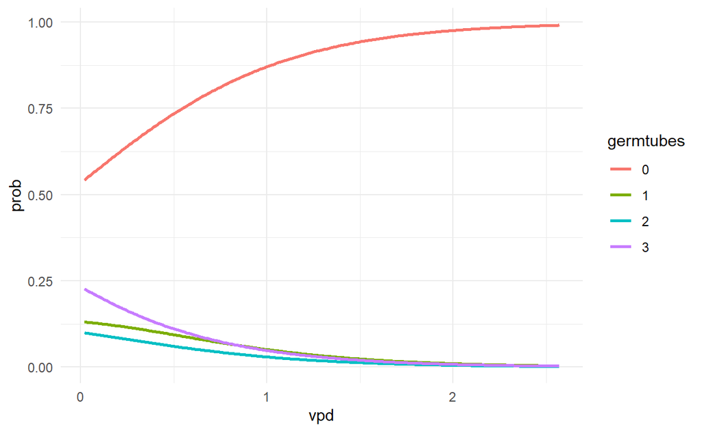

```r
m1_pred[,.(prob = mean(prob)),by= .(vpd,germtubes)] |>
   ggplot(aes(x = vpd, y = prob, colour = germtubes))+
#   facet_wrap(facets = vars(Tm))+
   geom_line(size = 1)+
   theme_minimal()
```

```r
m2 <- polr(germtubes ~ bs(vpd,knots = 0.5) + Tm + exp,
           weights = conidia,
           data = b_v, Hess = TRUE)
summary(m2)
```

```
Call:
polr(formula = germtubes ~ bs(vpd, knots = 0.5) + Tm + exp, data = b_v,
    weights = conidia, Hess = TRUE)

Coefficients:
                         Value Std. Error t value
bs(vpd, knots = 0.5)1 -4.80829   0.095654  -50.27
bs(vpd, knots = 0.5)2 -2.23386   0.160078  -13.95
bs(vpd, knots = 0.5)3 -5.39222   0.194772  -27.68
bs(vpd, knots = 0.5)4 -4.44845   0.113469  -39.20
Tm                     0.07002   0.007992    8.76
exp2                  -0.69700   0.048324  -14.42
exp3                  -0.77686   0.045167  -17.20

Intercepts:
    Value    Std. Error t value
0|1  -0.4810   0.2013    -2.3896
1|2   0.3077   0.2011     1.5304
2|3   1.0436   0.2014     5.1818

Residual Deviance: 24437.32
AIC: 24457.32
```

Let’s predict from this model to consider it’s performance.

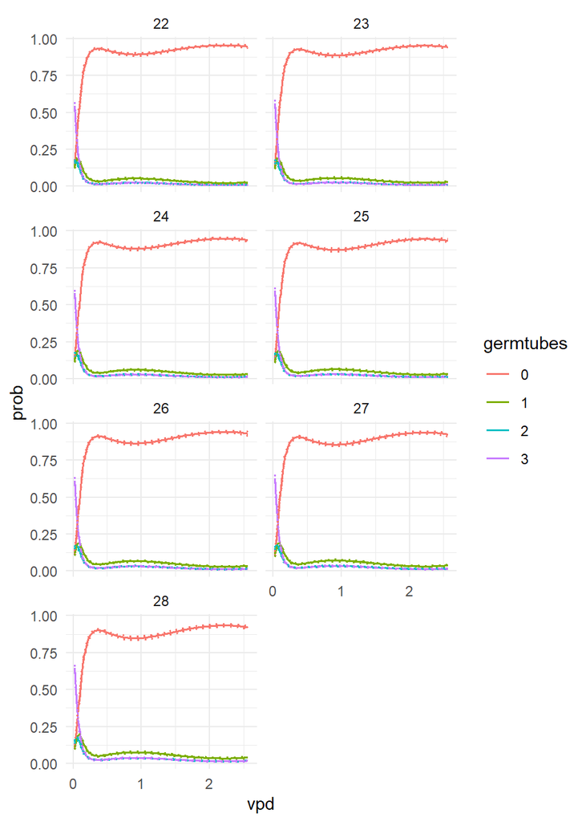

```r
# create a data.frame with predicted values and reference them to the respective temperature
m2_pred <- marginaleffects::predictions(m2,
                                        newdata = test_dat,
                                        type = "probs")
# set data.table format
setDT(m2_pred)

# calculate approximate confidence intervals
m2_pred[, CI_low := .(predicted - 1.96*std.error)]
m2_pred[, CI_high := .(predicted + 1.96*std.error)]

# change the column names
setnames(m2_pred,
         old = c("group","Tm.x","vpd.x"),
         new = c("germtubes", "Tm", "vpd"))

# summarise the 3 experiments into one
m2_plot <- m2_pred[,.(prob = mean(predicted),
           CI_l = mean(CI_low),
           CI_h = mean(CI_high)),
           by= .(vpd,Tm, germtubes)]

m2_plot |>
   ggplot(aes(x = vpd, y = prob, colour = germtubes))+
   geom_line(size = 0.7)+
   facet_wrap(facets = vars(Tm), ncol = 2)+
   geom_line(data = m2_plot, aes(x = vpd, y = CI_l, #colour = group,
                                 ), linetype = "dotted", size = 0.6)+
   geom_line(data = m2_plot, aes(x = vpd, y = CI_h, #colour = germtubes,
                                 ), linetype = "dotted", size = 0.6)+
   theme_minimal()
```

There is a consistent effect of temperature that increases the number of germinated and branching germ-tubes. Low VPD has a strong effect on the number and proportion of branching germtubes. While the number of germinated conidia and germ tube branching decreases rapidly as VPD increases, however after 0.5 kPa, the proportion of germinating and branching conidia stabilise all the way up to 2 kPa.

Lets look at just VPD and drop the temperature effect.

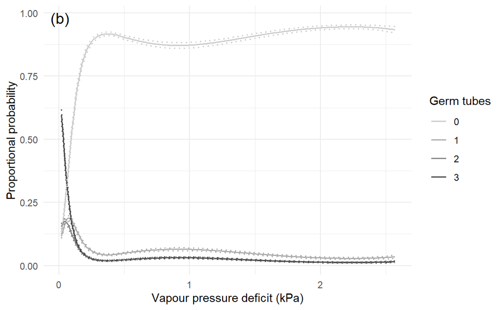

```r
# re-summarise the three experiments into one without looking at temperatures
m2_plot <- m2_pred[,.(prob = mean(predicted),
           CI_l = mean(CI_low),
           CI_h = mean(CI_high)),
           by= .(vpd, germtubes)]

# plot with confidence intervals
Figure_5b <-
   m2_plot |>
   ggplot(aes(x = vpd, y = prob, colour = germtubes))+
   geom_line(size = 0.7)+
   geom_line(data = m2_plot, aes(x = vpd, y = CI_l, colour = germtubes,
                                 ), linetype = "dotted", size = 0.6)+
   geom_line(data = m2_plot, aes(x = vpd, y = CI_h, colour = germtubes,
                                 ), linetype = "dotted", size = 0.6)+
   theme_minimal() +
   annotate("text", x = 0.01, y = 0.98, label = "(b)", size =5)+
   scale_color_grey(start = 0.8, end = 0.3)+
   xlab("Vapour pressure deficit (kPa)")+
   ylab("Proportional probability")+
   labs(colour = "Germ tubes")

Figure_5b
```

```r
# Save table as a word document
ggsave(
   filename = "FiguresTables/Fig5b_VPDGermtubeMod.tiff",
   plot = Figure_5b,
   device = "tiff",
   height = 5,
   width = 7,
   dpi = 300,
   units = "in"
)
```

Given the plots show a decent similarity to the raw data we will choose `m2`. Lets now extract the coefficients

```r
# get table of coefficients
coef_table <- data.table(coef(summary(m2)), keep.rownames = TRUE)

# calculate p-values
coef_table[, p_value := pnorm(abs(`t value`),lower.tail = FALSE) *2][, sig := p_star(p_value)]
coef_table
```

```
                       rn       Value  Std. Error    t value
 1: bs(vpd, knots = 0.5)1 -4.80829167 0.095653746 -50.267677
 2: bs(vpd, knots = 0.5)2 -2.23386481 0.160077935 -13.954858
 3: bs(vpd, knots = 0.5)3 -5.39221887 0.194771549 -27.684838
 4: bs(vpd, knots = 0.5)4 -4.44845006 0.113469356 -39.203977
 5:                    Tm  0.07001695 0.007992462   8.760374
 6:                  exp2 -0.69700190 0.048324305 -14.423423
 7:                  exp3 -0.77686230 0.045166989 -17.199781
 8:                   0|1 -0.48104065 0.201309824  -2.389554
 9:                   1|2  0.30770150 0.201058233   1.530410
10:                   2|3  1.04364994 0.201407804   5.181775
          p_value sig
 1:  0.000000e+00 ***
 2:  2.938875e-44 ***
 3: 1.063089e-168 ***
 4:  0.000000e+00 ***
 5:  1.946036e-18 ***
 6:  3.685972e-47 ***
 7:  2.665388e-66 ***
 8:  1.686885e-02   *
 9:  1.259153e-01
10:  2.197842e-07 ***
```